# Conditional extremes with evgam

Ben Youngman

2024-10-30

# 1 Outline

This vignette considers the Heffernan and Tawn (2004) conditional model for extremes in the form of Shooter et al. (2019), so for $Y_i \sim Laplace$

$$\begin{equation}
Z_{j \mid i} = \dfrac{Y_{j \mid i} - \alpha_{j \mid i} y_i}{y_i^{\beta_{j \mid i}}} \sim N(\mu_{j \mid i}, \sigma_{j \mid i}^2) \tag{1.1}
\end{equation}$$

with $-1 \leq \alpha_{j \mid i} \leq 1$, $0 \leq \beta_{j \mid i} \leq 1$, $\infty < \mu_{j \mid i} < \infty$ and $0 < \sigma_{j \mid i} < \infty$.

For a regression-type approach, suppose that

$$Y_{j \mid i} \sim N(\alpha_{j \mid i} y_i + y_i^{\beta_{j \mid i}} \mu_{j \mid i}, y_i^{2\beta_{j \mid i}} \sigma_{j \mid i}^2).$$

## 1.1 A GAM-based model

To illustrate a GAM-based approach, consider the spatial setting in which we’re interested in extremes at location $\mathbf{s}$ given location $\mathbf{s}_0$, so that

$$\begin{equation}
Y(\mathbf{s}) \mid y(\mathbf{s}_0) \sim N(\alpha(\mathbf{s}) y(\mathbf{s}_0) + \mu(\mathbf{s}) y(\mathbf{s}_0)^{\beta(\mathbf{s})}, y(\mathbf{s}_0)^{2 \beta(\mathbf{s})} \sigma(\mathbf{s})^2). \label\tag{1.2}
\end{equation}$$

Then, if we want to use a GAM-based formulation we can assume link functions $h_*()$ such that $\alpha(\mathbf{s}) = h_\alpha(\eta_\alpha(\mathbf{s}))$, $\beta(\mathbf{s}) = h_\beta(\eta_\beta(\mathbf{s}))$, $\mu(\mathbf{s}) = h_\mu(\eta_\mu(\mathbf{s}))$ and $\sigma(\mathbf{s}) = h_\sigma(\eta_\sigma(\mathbf{s}))$, with $h_\alpha(w) = 2 / (1 + \text{e}^{-w}) - 1$, $h_\beta(w) = 1 / (1 + \text{e}^{-w})$, $h_\mu(w) = w$ and $h_\sigma(w) = \text{e}^w$.

For the GAM part of the model we’ll assume that
$$\eta_*(\mathbf{s}) = \gamma_{*0} + g_*(\mathbf{s})$$
for intercept $\gamma_{*0}$ and where $g_*(\mathbf{s})$ denotes a thin-plate regression spline, except for $\beta$, which we assume to be constant.

# 2 Modelling Air Surface Skin Temperature

Here we’ll model MERRA-2’s air surface skin temperatures, as used in Lee et al. (2025).

## 2.1 Setting things up for `evgam`

```r
# remotes::install_github('byoungman/evgam')
library(evgam)
```

We’ll load the data, which arrive as separate yearly files, and then combine them.

```r
fls <- list.files('./Average surface skin temperature/', full.names = TRUE)

lst <- list()

for (i in seq_along(fls)) {
  load(fls[i])
  lst[[i]] <- list(dates = dates, locations = locations, day_SFT_max = day_SFT_max)
}

dates <- do.call(c, lapply(lst, '[[', 'dates'))
day_SFT_max <- t(do.call(rbind, lapply(lst, '[[', 'day_SFT_max')))
```

transform things to Laplace scale

```r
day_SFT_max_F <- t(apply(day_SFT_max, 1, function(x) (rank(x) - .5) / length(x)))

qlaplace <- function(p) {
  ifelse(p <= .5, log(2 * p), -log(2 * (1 - p)))
}

data_L <- qlaplace(day_SFT_max_F)
```

and then put its meta data in `data.frame` format

```r
grid_df <- data.frame(lon = locations[, 1], lat = locations[, 2])
d <- nrow(grid_df)
```

## 2.2 Single-site conditioning

We now need to condition on some site. Let’s choose the one in the middle.

```r
cond <- with(locations, which(lon == median(lon) & lat == median(lat)))
lon0 <- locations[cond, 1]
lat0 <- locations[cond, 2]
```

Then we want to find which data exceed some threshold at that site. We’ll choose the threshold to be the 0.8 quantile.

```r
threshold <- qlaplace(0.8)
exceed <- which(data_L[cond, ] > threshold)
```

Next we set up the conditioning data (I’ll probably write a fairly straightforward function to do this in future)

```r
cond_mat <- matrix(data_L[cond, ], nrow(data_L), ncol(data_L), byrow = TRUE)
ev_df_mat <- data.frame(lon = grid_df$lon[-cond], lat = grid_df$lat[-cond])
ev_df_mat$y <- data_L[-cond, exceed]
ev_df_mat$x <- cond_mat[-cond, exceed]
```

and then set up our formula for the conditional extreme value model’s four transformed parameters.

```r
fmla_condex <- list(
  y ~ s(lon, lat, k = 10),
    ~ 1,
    ~ s(lon, lat, k = 10),
    ~ s(lon, lat, k = 10)
)
```

The following fits the model

```r
m1 <- evgam(fmla_condex, data = ev_df_mat, family = 'condex', args = list(x = ev_df_mat$x))
```

Here’s a plot of the resulting parameter estimates.

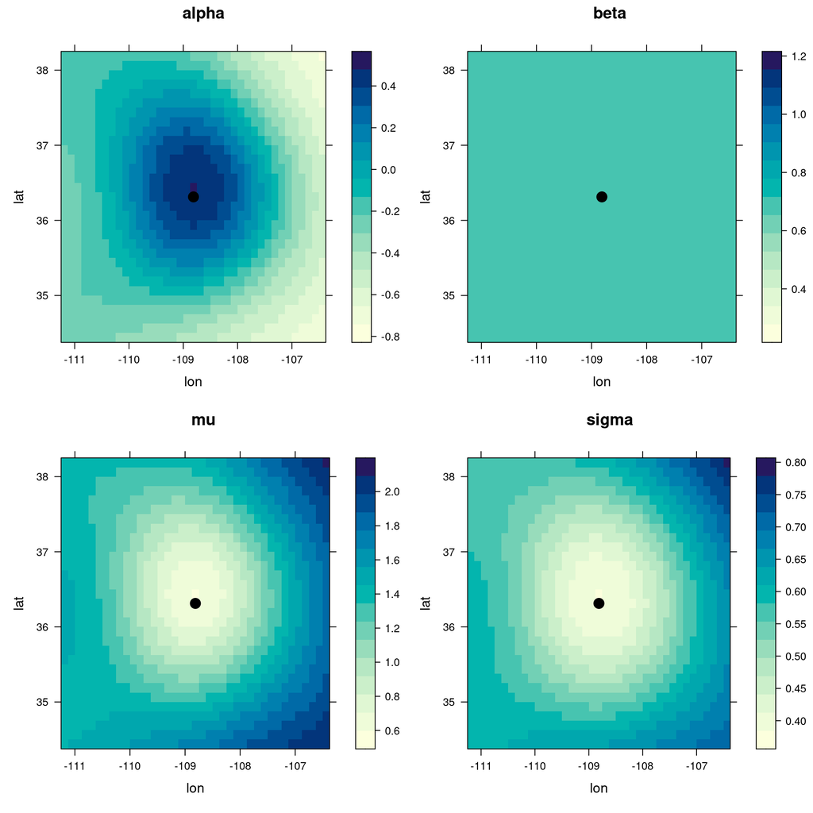

```r
library(lattice)
pred1 <- grid_df
pred1 <- cbind(pred1, predict(m1, newdata = grid_df, type = 'response'))
panel_fn <- function(...) {
            panel.levelplot(...)
            panel.xyplot(lon0, lat0, pch = 19, col = 1, cex = 1.5)
          }
l1 <- levelplot(alpha ~ lon * lat, pred1, main = 'alpha', panel = panel_fn)
l2 <- levelplot(beta ~ lon * lat, pred1, main = 'beta', panel = panel_fn)
l3 <- levelplot(location ~ lon * lat, pred1, main = 'mu', panel = panel_fn)
l4 <- levelplot(scale ~ lon * lat, pred1, main = 'sigma', panel = panel_fn)
print(l1, split = c(1, 1, 2, 2), more = TRUE)
print(l2, split = c(2, 1, 2, 2), more = TRUE)
print(l3, split = c(1, 2, 2, 2), more = TRUE)
print(l4, split = c(2, 2, 2, 2))
```

## 2.3 Composite fitting for multiple conditioning sites

To fit based on multiple conditioning sites, we can adopt the model

$$\begin{equation}
Y(\mathbf{s}- \mathbf{s}_{0i}) \mid y(\mathbf{s}_{0i}) \sim N(\alpha(\mathbf{s}- \mathbf{s}_{0i}) y(\mathbf{s}_{0i}) + \mu(\mathbf{s}- \mathbf{s}_{0i}) y(\mathbf{s}_{0i})^{\beta(\mathbf{s}- \mathbf{s}_{0i})}, y(\mathbf{s}_{0i})^{2 \beta(\mathbf{s}- \mathbf{s}_{0i})} \sigma(\mathbf{s}- \mathbf{s}_{0i})^2), \tag{2.1}
\end{equation}$$

where $i = 1, \ldots, m$ indexes conditioning site.

The following creates a `data.frame` comprising $m = 5$ conditioning sites (which can almost certainly be done much more compactly).

```r
ncond <- 5
cond_vec <- round(nrow(grid_df) * (1:ncond - .5) / ncond)
ncol <- max(rowSums(data_L[cond_vec, ] > threshold))
mat0 <- matrix(NA, nrow(data_L) - 1, ncol)
ev_df_list <- list()

for (i in 1:ncond) {
  cond <- cond_vec[i]
  lon0 <- grid_df[cond, 'lon']
  lat0 <- grid_df[cond, 'lat']
  ev_df_i <- data.frame(lon = grid_df$lon[-cond], lat = grid_df$lat[-cond])
  ev_df_i$lon2  <- ev_df_i$lon - lon0
  ev_df_i$lat2  <- ev_df_i$lat - lat0
  matx <- maty <- mat0
  exceed <- which(data_L[cond, ] > threshold)
  maty[, seq_along(exceed)] <- data_L[-cond, exceed]
  ev_df_i$y <- maty
  cond_mat <- matrix(data_L[cond, ], nrow(data_L), ncol(data_L), byrow = TRUE)
  matx[, seq_along(exceed)] <- cond_mat[-cond, exceed]
  ev_df_i$x <- matx
  ev_df_i$weights <- 0 * maty+ 1 / ncond
  ev_df_list[[i]] <- ev_df_i
}

ev_df_comp <- do.call(rbind, lapply(ev_df_list, function(x) x[, c('lon', 'lat', 'lon2', 'lat2')]))
ev_df_comp$y <- do.call(rbind, lapply(ev_df_list, function(x) x$y))
ev_df_comp$x <- do.call(rbind, lapply(ev_df_list, function(x) x$x))
ev_df_comp$weights <- do.call(rbind, lapply(ev_df_list, function(x) x$weights))
```

We then update the model formula to allow for the centered coordinates and then fit the model

```r
fmla_condex2 <- list(
  y ~ s(lon2, lat2, k = 10),
    ~ 1,
    ~ s(lon2, lat2, k = 10),
    ~ s(lon2, lat2, k = 10)
)

m2 <- evgam(fmla_condex2, data = ev_df_comp, family = 'condex',
            args = list(x = ev_df_comp$x, weights = ev_df_comp$weights))
```

which takes about 15 minutes.

Finally, we’ll plot the estimates from the centered model.

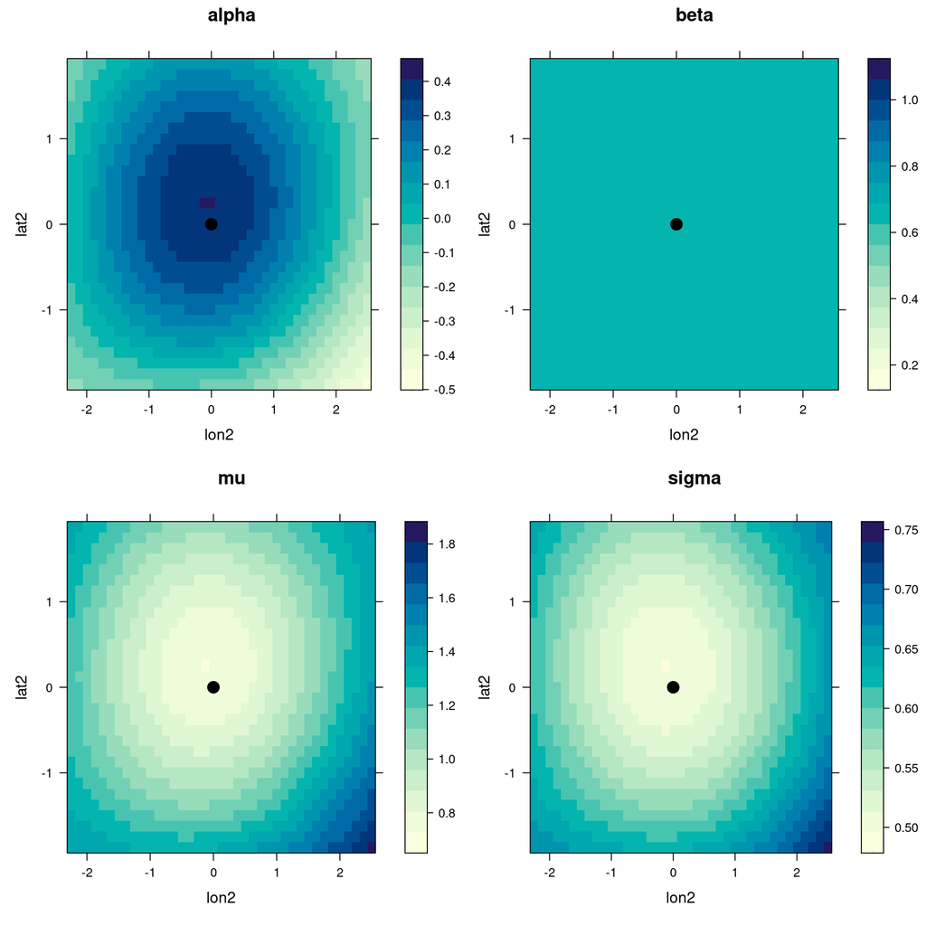

```r
cond <- round(nrow(grid_df) / 2)
lon0 <- grid_df[cond, 'lon']
lat0 <- grid_df[cond, 'lat']
pred2 <- grid_df
pred2$lon2 <- pred2$lon - lon0
pred2$lat2 <- pred2$lat - lat0
pred2 <- cbind(pred2, predict(m2, newdata = pred2, type = 'response'))
panel_fn2 <- function(...) {
            panel.levelplot(...)
            panel.xyplot(0, 0, pch = 19, col = 1, cex = 1.5)
          }
l1 <- levelplot(alpha ~ lon2 * lat2, pred2, main = 'alpha', panel = panel_fn2)
l2 <- levelplot(beta ~ lon2 * lat2, pred2, main = 'beta', panel = panel_fn2)
l3 <- levelplot(location ~ lon2 * lat2, pred2, main = 'mu', panel = panel_fn2)
l4 <- levelplot(scale ~ lon2 * lat2, pred2, main = 'sigma', panel = panel_fn2)
print(l1, split = c(1, 1, 2, 2), more = TRUE)
print(l2, split = c(2, 1, 2, 2), more = TRUE)
print(l3, split = c(1, 2, 2, 2), more = TRUE)
print(l4, split = c(2, 2, 2, 2))
```

# 3 Some points

- There is nothing to impose that $\alpha(\mathbf{s}_0) = 1$ in Eq. (1.2) or that $\alpha(\mathbf{0}) = 1$ in Eq. (2.1).
- There are no monotonicity constraints, i.e. that $\alpha(\mathbf{s}- \mathbf{s}_0)$ decreases with increasing $||\mathbf{s}- \mathbf{s}_0||$.

# 4 Thanks

I thank Jordan Richards, Jenny Wadsworth, Emma Simpson and Simon Brown for their insights into the conditional extreme value model, which have fed into the code, these data used, and this vignette.

# References

Heffernan, Janet E, and Jonathan A Tawn. 2004. “A Conditional Approach for Multivariate Extreme Values (with Discussion).” *Journal of the Royal Statistical Society Series B: Statistical Methodology* 66 (3): 497–546.

Lee, B. S., R. Majumder, J. Richards, E. S. Simpson, and L. Zhang. 2025. “An Extensive Comparative Study Among Spatial Extremes Models and Their Inference on Large Spatial Observations.”

Shooter, R., E. Ross, J. Tawn, and P. Jonathan. 2019. “On Spatial Conditional Extremes for Ocean Storm Severity.” *Environmetrics*. https://doi.org/https://doi.org/10.1002/env.2562.